# My first assignment in reproducible research

### Loading and preprocessing the data

The following chuck of code load the data, and filter out the missing values

```r
data<-read.csv("C:\\activity.csv")
a<- is.na(data$steps)
data<- data[!a,]
data$date<- droplevels(data$date)
```

1.Calculate the total number of steps taken per day

```r
totalSteps<- tapply(data$steps,data$date,sum)
print(totalSteps)
```

```
## 2012-10-02 2012-10-03 2012-10-04 2012-10-05 2012-10-06 2012-10-07
##        126      11352      12116      13294      15420      11015
## 2012-10-09 2012-10-10 2012-10-11 2012-10-12 2012-10-13 2012-10-14
##      12811       9900      10304      17382      12426      15098
## 2012-10-15 2012-10-16 2012-10-17 2012-10-18 2012-10-19 2012-10-20
##      10139      15084      13452      10056      11829      10395
## 2012-10-21 2012-10-22 2012-10-23 2012-10-24 2012-10-25 2012-10-26
##       8821      13460       8918       8355       2492       6778
## 2012-10-27 2012-10-28 2012-10-29 2012-10-30 2012-10-31 2012-11-02
##      10119      11458       5018       9819      15414      10600
## 2012-11-03 2012-11-05 2012-11-06 2012-11-07 2012-11-08 2012-11-11
##      10571      10439       8334      12883       3219      12608
## 2012-11-12 2012-11-13 2012-11-15 2012-11-16 2012-11-17 2012-11-18
##      10765       7336         41       5441      14339      15110
## 2012-11-19 2012-11-20 2012-11-21 2012-11-22 2012-11-23 2012-11-24
##       8841       4472      12787      20427      21194      14478
## 2012-11-25 2012-11-26 2012-11-27 2012-11-28 2012-11-29
##      11834      11162      13646      10183       7047
```

2.Histogram of the total number of steps taken each day

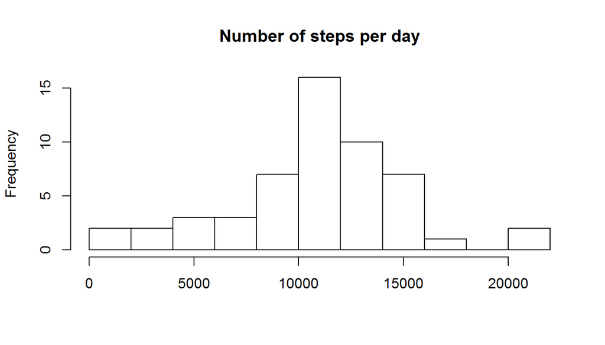

```r
hist(totalSteps,breaks=10,main="Number of steps per day",xlab="")
```

### What is the average daily activity pattern?

1.Make a time series plot of the 5-minute interval (x-axis) and the average number of steps taken, averaged across all days (y-axis)

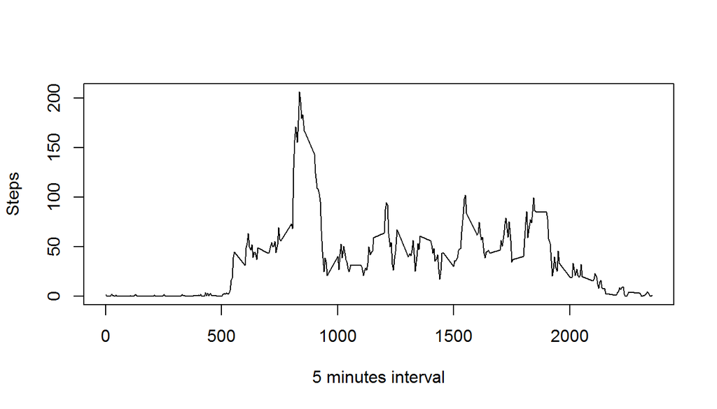

```r
aveSteps=tapply(data$steps,data$interval,mean)
plot(x=as.numeric(names(aveSteps)),y=aveSteps,type="l",xlab="5 minutes interval",ylab="Steps")
```

2.Which 5-minute interval, on average across all the days in the dataset, contains the maximum number of steps?

The 5-minute interval contains the maximum number of steps is 835, the maximum number of the steps is 206.1698113.

### Imputing missing values

1.Calculate and report the total number of missing values in the dataset.

```r
data2<-read.csv("C:\\activity.csv")
a<- is.na(data2$steps)
print(paste("The total number of missing values are", sum(a)))
```

```
## [1] "The total number of missing values are 2304"
```

2 and 3.Devise a strategy for filling in all of the missing values in the dataset and Create a new dataset that is equal to the original dataset but with the missing data filled in. The following code filled the missing values with average values.

```r
for(i in 1:nrow(data2))
    {
        if(is.na(data2[i,"steps"]))  data2$steps[i]<- aveSteps[as.character(data2$interval[i])]
    }
```

4.Make a histogram of the total number of steps taken each day.

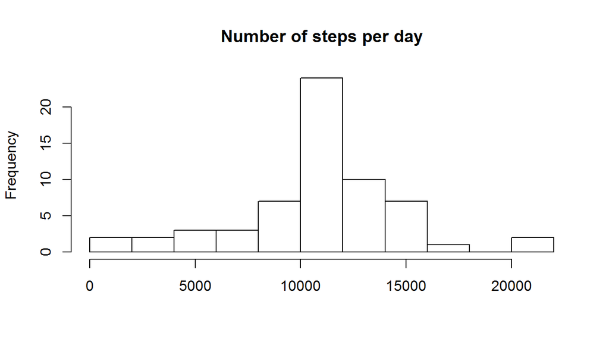

```r
totalSteps2<- tapply(data2$steps,data2$date,sum)
hist(totalSteps2,breaks=10,main="Number of steps per day",xlab="")
```

### differences in activity patterns between weekdays and weekends

1.Create a new factor variable in the dataset with two levels - “weekday” and “weekend”

```r
days<- weekdays(as.Date(data2$date,format="%Y-%m-%d"))
days<- as.factor(days)
levels(days)[levels(days)=="Monday"|levels(days)=="Tuesday"|levels(days)=="Wednesday"|levels(days)=="Thursday"|levels(days)=="Friday"]<- "weekdays"
levels(days)[levels(days)=="Saturday"|levels(days)=="Sunday"]<- "weekend"
data2<- cbind(data2,days)
```

2.Make a panel plot containing a time series plot

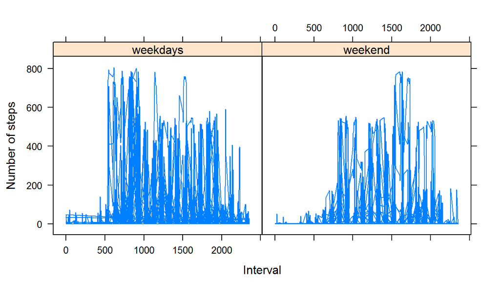

```r
library(lattice)
p<-xyplot(steps~interval|days,data=data2,xlab="Interval",ylab="Number of steps",type="l")
print(p)
```